# Risk Factor Analysis

## Outcome Variable

**Outcome Variable:** sstunted

## Predictor Variables

**Intervention Variable:** nchldlt5

**Adjustment Set:**

unadjusted

## Stratifying Variables

The analysis was stratified on these variable(s):

- agecat
- studyid
- country

## Data Summary

| agecat | studyid | country | A | n | nA | nAY0 | nAY1 |
| --- | --- | --- | --- | --- | --- | --- | --- |
| Birth | ki1000108-IRC | INDIA | 1 | 388 | 84 | 79 | 5 |
| Birth | ki1000108-IRC | INDIA | 2 | 388 | 114 | 108 | 6 |
| Birth | ki1000108-IRC | INDIA | 3+ | 388 | 190 | 185 | 5 |
| Birth | ki1017093c-NIH-Crypto | BANGLADESH | 1 | 27 | 18 | 17 | 1 |
| Birth | ki1017093c-NIH-Crypto | BANGLADESH | 2 | 27 | 8 | 8 | 0 |
| Birth | ki1017093c-NIH-Crypto | BANGLADESH | 3+ | 27 | 1 | 1 | 0 |
| Birth | kiGH5241-JiVitA-3 | BANGLADESH | 1 | 9732 | 6009 | 5225 | 784 |
| Birth | kiGH5241-JiVitA-3 | BANGLADESH | 2 | 9732 | 3484 | 3195 | 289 |
| Birth | kiGH5241-JiVitA-3 | BANGLADESH | 3+ | 9732 | 239 | 216 | 23 |
| 3 months | ki1000108-IRC | INDIA | 1 | 407 | 89 | 77 | 12 |
| 3 months | ki1000108-IRC | INDIA | 2 | 407 | 117 | 107 | 10 |
| 3 months | ki1000108-IRC | INDIA | 3+ | 407 | 201 | 187 | 14 |
| 3 months | ki1017093b-PROVIDE | BANGLADESH | 1 | 645 | 474 | 466 | 8 |
| 3 months | ki1017093b-PROVIDE | BANGLADESH | 2 | 645 | 161 | 159 | 2 |
| 3 months | ki1017093b-PROVIDE | BANGLADESH | 3+ | 645 | 10 | 10 | 0 |
| 3 months | ki1017093c-NIH-Crypto | BANGLADESH | 1 | 728 | 518 | 494 | 24 |
| 3 months | ki1017093c-NIH-Crypto | BANGLADESH | 2 | 728 | 204 | 195 | 9 |
| 3 months | ki1017093c-NIH-Crypto | BANGLADESH | 3+ | 728 | 6 | 6 | 0 |
| 3 months | ki1066203-TanzaniaChild2 | TANZANIA, UNITED REPUBLIC OF | 1 | 2283 | 1560 | 1543 | 17 |
| 3 months | ki1066203-TanzaniaChild2 | TANZANIA, UNITED REPUBLIC OF | 2 | 2283 | 650 | 644 | 6 |
| 3 months | ki1066203-TanzaniaChild2 | TANZANIA, UNITED REPUBLIC OF | 3+ | 2283 | 73 | 73 | 0 |
| 3 months | kiGH5241-JiVitA-3 | BANGLADESH | 1 | 12292 | 7835 | 7109 | 726 |
| 3 months | kiGH5241-JiVitA-3 | BANGLADESH | 2 | 12292 | 4182 | 3902 | 280 |
| 3 months | kiGH5241-JiVitA-3 | BANGLADESH | 3+ | 12292 | 275 | 256 | 19 |
| 6 months | ki1000108-IRC | INDIA | 1 | 407 | 89 | 78 | 11 |
| 6 months | ki1000108-IRC | INDIA | 2 | 407 | 119 | 112 | 7 |
| 6 months | ki1000108-IRC | INDIA | 3+ | 407 | 199 | 188 | 11 |
| 6 months | ki1017093b-PROVIDE | BANGLADESH | 1 | 583 | 426 | 416 | 10 |
| 6 months | ki1017093b-PROVIDE | BANGLADESH | 2 | 583 | 148 | 144 | 4 |
| 6 months | ki1017093b-PROVIDE | BANGLADESH | 3+ | 583 | 9 | 9 | 0 |

[output cut: 84 more lines]

The following strata were considered:

- agecat: 12 months, studyid: ki1000108-IRC, country: INDIA
- agecat: 12 months, studyid: ki1017093b-PROVIDE, country: BANGLADESH
- agecat: 12 months, studyid: ki1017093c-NIH-Crypto, country: BANGLADESH
- agecat: 12 months, studyid: ki1066203-TanzaniaChild2, country: TANZANIA, UNITED REPUBLIC OF
- agecat: 12 months, studyid: ki1148112-LCNI-5, country: MALAWI
- agecat: 12 months, studyid: kiGH5241-JiVitA-3, country: BANGLADESH
- agecat: 18 months, studyid: ki1000108-IRC, country: INDIA
- agecat: 18 months, studyid: ki1017093b-PROVIDE, country: BANGLADESH
- agecat: 18 months, studyid: ki1017093c-NIH-Crypto, country: BANGLADESH
- agecat: 18 months, studyid: ki1066203-TanzaniaChild2, country: TANZANIA, UNITED REPUBLIC OF
- agecat: 18 months, studyid: ki1112895-iLiNS-Zinc, country: BURKINA FASO
- agecat: 18 months, studyid: ki1148112-LCNI-5, country: MALAWI
- agecat: 24 months, studyid: ki1000108-IRC, country: INDIA
- agecat: 24 months, studyid: ki1017093b-PROVIDE, country: BANGLADESH
- agecat: 24 months, studyid: ki1017093c-NIH-Crypto, country: BANGLADESH
- agecat: 24 months, studyid: ki1066203-TanzaniaChild2, country: TANZANIA, UNITED REPUBLIC OF
- agecat: 24 months, studyid: ki1148112-LCNI-5, country: MALAWI
- agecat: 24 months, studyid: kiGH5241-JiVitA-3, country: BANGLADESH
- agecat: 3 months, studyid: ki1000108-IRC, country: INDIA
- agecat: 3 months, studyid: ki1017093b-PROVIDE, country: BANGLADESH
- agecat: 3 months, studyid: ki1017093c-NIH-Crypto, country: BANGLADESH
- agecat: 3 months, studyid: ki1066203-TanzaniaChild2, country: TANZANIA, UNITED REPUBLIC OF
- agecat: 3 months, studyid: kiGH5241-JiVitA-3, country: BANGLADESH
- agecat: 6 months, studyid: ki1000108-IRC, country: INDIA
- agecat: 6 months, studyid: ki1017093b-PROVIDE, country: BANGLADESH
- agecat: 6 months, studyid: ki1017093c-NIH-Crypto, country: BANGLADESH
- agecat: 6 months, studyid: ki1066203-TanzaniaChild2, country: TANZANIA, UNITED REPUBLIC OF
- agecat: 6 months, studyid: ki1148112-LCNI-5, country: MALAWI
- agecat: 6 months, studyid: kiGH5241-JiVitA-3, country: BANGLADESH
- agecat: 9 months, studyid: ki1000108-IRC, country: INDIA
- agecat: 9 months, studyid: ki1017093b-PROVIDE, country: BANGLADESH
- agecat: 9 months, studyid: ki1017093c-NIH-Crypto, country: BANGLADESH
- agecat: 9 months, studyid: ki1066203-TanzaniaChild2, country: TANZANIA, UNITED REPUBLIC OF
- agecat: 9 months, studyid: ki1112895-iLiNS-Zinc, country: BURKINA FASO
- agecat: 9 months, studyid: ki1148112-LCNI-5, country: MALAWI
- agecat: Birth, studyid: ki1000108-IRC, country: INDIA
- agecat: Birth, studyid: ki1017093c-NIH-Crypto, country: BANGLADESH
- agecat: Birth, studyid: kiGH5241-JiVitA-3, country: BANGLADESH

### Dropped Strata

Some strata were dropped due to rare outcomes:

- agecat: Birth, studyid: ki1017093c-NIH-Crypto, country: BANGLADESH
- agecat: 3 months, studyid: ki1017093b-PROVIDE, country: BANGLADESH
- agecat: 3 months, studyid: ki1017093c-NIH-Crypto, country: BANGLADESH
- agecat: 3 months, studyid: ki1066203-TanzaniaChild2, country: TANZANIA, UNITED REPUBLIC OF
- agecat: 6 months, studyid: ki1017093b-PROVIDE, country: BANGLADESH
- agecat: 6 months, studyid: ki1017093c-NIH-Crypto, country: BANGLADESH
- agecat: 6 months, studyid: ki1066203-TanzaniaChild2, country: TANZANIA, UNITED REPUBLIC OF
- agecat: 9 months, studyid: ki1017093b-PROVIDE, country: BANGLADESH
- agecat: 9 months, studyid: ki1017093c-NIH-Crypto, country: BANGLADESH
- agecat: 9 months, studyid: ki1066203-TanzaniaChild2, country: TANZANIA, UNITED REPUBLIC OF
- agecat: 12 months, studyid: ki1017093b-PROVIDE, country: BANGLADESH
- agecat: 12 months, studyid: ki1017093c-NIH-Crypto, country: BANGLADESH
- agecat: 12 months, studyid: ki1066203-TanzaniaChild2, country: TANZANIA, UNITED REPUBLIC OF
- agecat: 12 months, studyid: ki1148112-LCNI-5, country: MALAWI
- agecat: 18 months, studyid: ki1017093b-PROVIDE, country: BANGLADESH
- agecat: 18 months, studyid: ki1017093c-NIH-Crypto, country: BANGLADESH
- agecat: 18 months, studyid: ki1066203-TanzaniaChild2, country: TANZANIA, UNITED REPUBLIC OF
- agecat: 24 months, studyid: ki1017093b-PROVIDE, country: BANGLADESH
- agecat: 24 months, studyid: ki1017093c-NIH-Crypto, country: BANGLADESH
- agecat: 24 months, studyid: ki1066203-TanzaniaChild2, country: TANZANIA, UNITED REPUBLIC OF

## Methods Detail

We’re interested in the causal parameters $E[Y_a]$ for all values of $a \in \mathcal{A}$. These parameters represent the mean outcome if, possibly contrary to fact, we intervened to set all units to have $A=a$. Under the randomization and positivity assumptions, these are identified by the statistical parameters $\psi_a=E_W[E_{Y|A,W}(Y|A=a,W)]$. In addition, we’re interested in the mean of $Y$, $E[Y]$ under no intervention (the observed mean). We will estimate these parameters by using SuperLearner to fit the relevant likelihood factors – $E_{Y|A,W}(Y|A=a,W)$ and $p(A=a|W)$, and then updating our likelihood fit using a joint TMLE.

For unadjusted analyses ($W=\{\}$), initial likelihoods were estimated using Lrnr_glm to estimate the simple $E(Y|A)$ and Lrnr_mean to estimate $p(A)$. For adjusted analyses, a small library containing Lrnr_glmnet, Lrnr_xgboost, and Lrnr_mean was used.

Having estimated these parameters, we will then use the delta method to estimate relative risks and attributable risks relative to a prespecified baseline level of $A$.

# Results Detail

## Results Plots

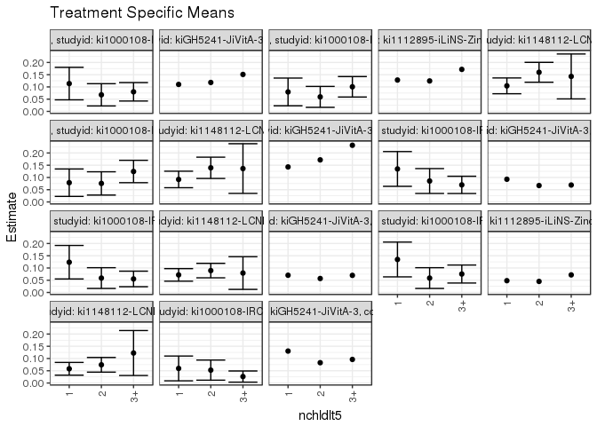

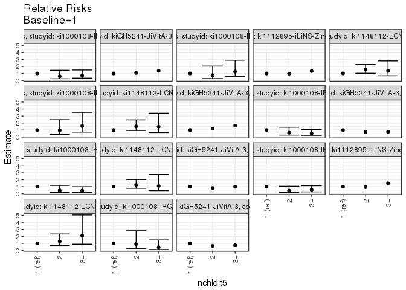

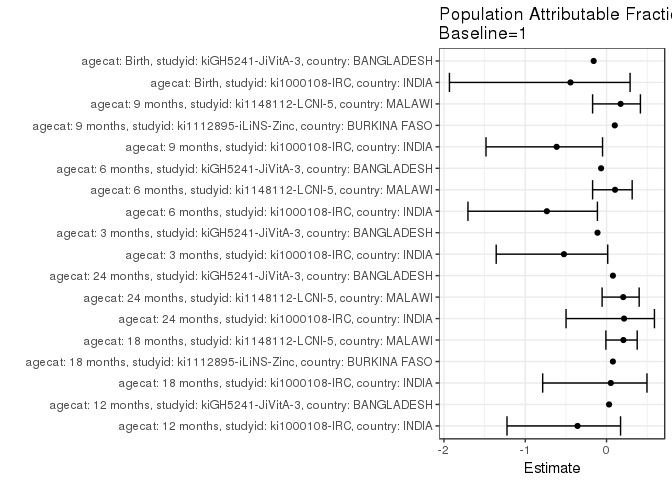

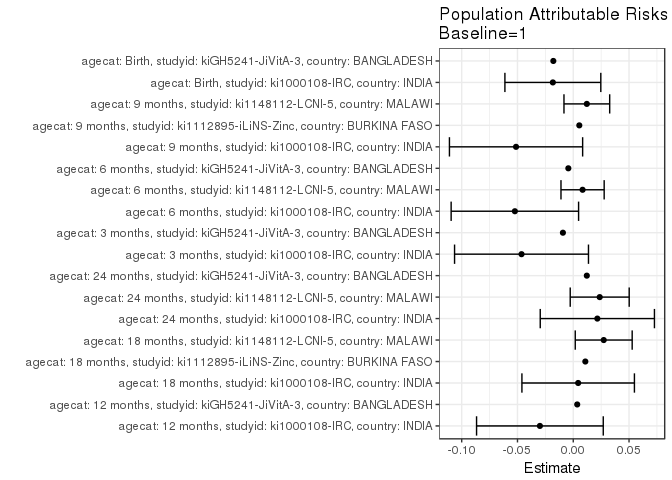

## Results Table

### Parameter: TSM

| agecat | studyid | country | intervention_level | baseline_level | estimate | ci_lower | ci_upper |
| --- | --- | --- | --- | --- | --- | --- | --- |
| Birth | ki1000108-IRC | INDIA | 1 | NA | 0.0595238 | 0.0088611 | 0.1101865 |
| Birth | ki1000108-IRC | INDIA | 2 | NA | 0.0526316 | 0.0115886 | 0.0936745 |
| Birth | ki1000108-IRC | INDIA | 3+ | NA | 0.0263158 | 0.0035255 | 0.0491060 |
| Birth | kiGH5241-JiVitA-3 | BANGLADESH | 1 | NA | 0.1304710 | NA | NA |
| Birth | kiGH5241-JiVitA-3 | BANGLADESH | 2 | NA | 0.0829506 | NA | NA |
| Birth | kiGH5241-JiVitA-3 | BANGLADESH | 3+ | NA | 0.0962343 | NA | NA |
| 3 months | ki1000108-IRC | INDIA | 1 | NA | 0.1348315 | 0.0637865 | 0.2058764 |
| 3 months | ki1000108-IRC | INDIA | 2 | NA | 0.0854701 | 0.0347482 | 0.1361920 |
| 3 months | ki1000108-IRC | INDIA | 3+ | NA | 0.0696517 | 0.0344168 | 0.1048866 |
| 3 months | kiGH5241-JiVitA-3 | BANGLADESH | 1 | NA | 0.0926611 | NA | NA |
| 3 months | kiGH5241-JiVitA-3 | BANGLADESH | 2 | NA | 0.0669536 | NA | NA |
| 3 months | kiGH5241-JiVitA-3 | BANGLADESH | 3+ | NA | 0.0690909 | NA | NA |
| 6 months | ki1000108-IRC | INDIA | 1 | NA | 0.1235955 | 0.0551349 | 0.1920561 |
| 6 months | ki1000108-IRC | INDIA | 2 | NA | 0.0588235 | 0.0164963 | 0.1011508 |
| 6 months | ki1000108-IRC | INDIA | 3+ | NA | 0.0552764 | 0.0234873 | 0.0870655 |
| 6 months | ki1148112-LCNI-5 | MALAWI | 1 | NA | 0.0717949 | 0.0461587 | 0.0974310 |
| 6 months | ki1148112-LCNI-5 | MALAWI | 2 | NA | 0.0893855 | 0.0598138 | 0.1189571 |
| 6 months | ki1148112-LCNI-5 | MALAWI | 3+ | NA | 0.0793651 | 0.0125762 | 0.1461540 |
| 6 months | kiGH5241-JiVitA-3 | BANGLADESH | 1 | NA | 0.0703387 | NA | NA |
| 6 months | kiGH5241-JiVitA-3 | BANGLADESH | 2 | NA | 0.0570494 | NA | NA |
| 6 months | kiGH5241-JiVitA-3 | BANGLADESH | 3+ | NA | 0.0698925 | NA | NA |
| 9 months | ki1000108-IRC | INDIA | 1 | NA | 0.1348315 | 0.0637865 | 0.2058764 |
| 9 months | ki1000108-IRC | INDIA | 2 | NA | 0.0588235 | 0.0164963 | 0.1011508 |
| 9 months | ki1000108-IRC | INDIA | 3+ | NA | 0.0753769 | 0.0386523 | 0.1121015 |
| 9 months | ki1112895-iLiNS-Zinc | BURKINA FASO | 1 | NA | 0.0481928 | NA | NA |
| 9 months | ki1112895-iLiNS-Zinc | BURKINA FASO | 2 | NA | 0.0451389 | NA | NA |
| 9 months | ki1112895-iLiNS-Zinc | BURKINA FASO | 3+ | NA | 0.0717703 | NA | NA |
| 9 months | ki1148112-LCNI-5 | MALAWI | 1 | NA | 0.0580645 | 0.0320111 | 0.0841180 |
| 9 months | ki1148112-LCNI-5 | MALAWI | 2 | NA | 0.0743243 | 0.0444203 | 0.1042283 |
| 9 months | ki1148112-LCNI-5 | MALAWI | 3+ | NA | 0.1224490 | 0.0305955 | 0.2143025 |
| 12 months | ki1000108-IRC | INDIA | 1 | NA | 0.1136364 | 0.0472457 | 0.1800270 |
| 12 months | ki1000108-IRC | INDIA | 2 | NA | 0.0677966 | 0.0223813 | 0.1132119 |
| 12 months | ki1000108-IRC | INDIA | 3+ | NA | 0.0800000 | 0.0423550 | 0.1176450 |
| 12 months | kiGH5241-JiVitA-3 | BANGLADESH | 1 | NA | 0.1101804 | NA | NA |
| 12 months | kiGH5241-JiVitA-3 | BANGLADESH | 2 | NA | 0.1181894 | NA | NA |
| 12 months | kiGH5241-JiVitA-3 | BANGLADESH | 3+ | NA | 0.1509434 | NA | NA |
| 18 months | ki1000108-IRC | INDIA | 1 | NA | 0.0795455 | 0.0229408 | 0.1361501 |
| 18 months | ki1000108-IRC | INDIA | 2 | NA | 0.0593220 | 0.0166471 | 0.1019969 |
| 18 months | ki1000108-IRC | INDIA | 3+ | NA | 0.1005025 | 0.0586765 | 0.1423286 |
| 18 months | ki1112895-iLiNS-Zinc | BURKINA FASO | 1 | NA | 0.1282051 | NA | NA |
| 18 months | ki1112895-iLiNS-Zinc | BURKINA FASO | 2 | NA | 0.1244635 | NA | NA |
| 18 months | ki1112895-iLiNS-Zinc | BURKINA FASO | 3+ | NA | 0.1715976 | NA | NA |
| 18 months | ki1148112-LCNI-5 | MALAWI | 1 | NA | 0.1043478 | 0.0720663 | 0.1366294 |
| 18 months | ki1148112-LCNI-5 | MALAWI | 2 | NA | 0.1597444 | 0.1191283 | 0.2003606 |
| 18 months | ki1148112-LCNI-5 | MALAWI | 3+ | NA | 0.1428571 | 0.0511431 | 0.2345712 |
| 24 months | ki1000108-IRC | INDIA | 1 | NA | 0.0786517 | 0.0226565 | 0.1346469 |
| 24 months | ki1000108-IRC | INDIA | 2 | NA | 0.0756303 | 0.0280664 | 0.1231941 |
| 24 months | ki1000108-IRC | INDIA | 3+ | NA | 0.1243781 | 0.0786996 | 0.1700566 |
| 24 months | ki1148112-LCNI-5 | MALAWI | 1 | NA | 0.0918728 | 0.0581904 | 0.1255551 |
| 24 months | ki1148112-LCNI-5 | MALAWI | 2 | NA | 0.1393443 | 0.0958539 | 0.1828346 |
| 24 months | ki1148112-LCNI-5 | MALAWI | 3+ | NA | 0.1363636 | 0.0348751 | 0.2378522 |
| 24 months | kiGH5241-JiVitA-3 | BANGLADESH | 1 | NA | 0.1429627 | NA | NA |
| 24 months | kiGH5241-JiVitA-3 | BANGLADESH | 2 | NA | 0.1718750 | NA | NA |
| 24 months | kiGH5241-JiVitA-3 | BANGLADESH | 3+ | NA | 0.2314815 | NA | NA |

### Parameter: E(Y)

| agecat | studyid | country | intervention_level | baseline_level | estimate | ci_lower | ci_upper |
| --- | --- | --- | --- | --- | --- | --- | --- |
| Birth | ki1000108-IRC | INDIA | NA | NA | 0.0412371 | 0.0214268 | 0.0610475 |
| Birth | kiGH5241-JiVitA-3 | BANGLADESH | NA | NA | 0.1126182 | NA | NA |
| 3 months | ki1000108-IRC | INDIA | NA | NA | 0.0884521 | 0.0608318 | 0.1160724 |
| 3 months | kiGH5241-JiVitA-3 | BANGLADESH | NA | NA | 0.0833876 | NA | NA |
| 6 months | ki1000108-IRC | INDIA | NA | NA | 0.0712531 | 0.0462303 | 0.0962759 |
| 6 months | ki1148112-LCNI-5 | MALAWI | NA | NA | 0.0801480 | 0.0614493 | 0.0988466 |
| 6 months | kiGH5241-JiVitA-3 | BANGLADESH | NA | NA | 0.0659288 | NA | NA |
| 9 months | ki1000108-IRC | INDIA | NA | NA | 0.0835381 | 0.0566237 | 0.1104525 |
| 9 months | ki1112895-iLiNS-Zinc | BURKINA FASO | NA | NA | 0.0536193 | NA | NA |
| 9 months | ki1148112-LCNI-5 | MALAWI | NA | NA | 0.0702290 | 0.0506448 | 0.0898132 |
| 12 months | ki1000108-IRC | INDIA | NA | NA | 0.0837438 | 0.0567661 | 0.1107216 |
| 12 months | kiGH5241-JiVitA-3 | BANGLADESH | NA | NA | 0.1137342 | NA | NA |
| 18 months | ki1000108-IRC | INDIA | NA | NA | 0.0839506 | 0.0569092 | 0.1109920 |
| 18 months | ki1112895-iLiNS-Zinc | BURKINA FASO | NA | NA | 0.1390285 | NA | NA |
| 18 months | ki1148112-LCNI-5 | MALAWI | NA | NA | 0.1316527 | 0.1068348 | 0.1564706 |
| 24 months | ki1000108-IRC | INDIA | NA | NA | 0.1002445 | 0.0711031 | 0.1293859 |
| 24 months | ki1148112-LCNI-5 | MALAWI | NA | NA | 0.1155867 | 0.0893389 | 0.1418344 |
| 24 months | kiGH5241-JiVitA-3 | BANGLADESH | NA | NA | 0.1551201 | NA | NA |

### Parameter: RR

| agecat | studyid | country | intervention_level | baseline_level | estimate | ci_lower | ci_upper |
| --- | --- | --- | --- | --- | --- | --- | --- |
| Birth | ki1000108-IRC | INDIA | 1 | 1 | 1.0000000 | 1.0000000 | 1.0000000 |
| Birth | ki1000108-IRC | INDIA | 2 | 1 | 0.8842105 | 0.2787563 | 2.8047016 |
| Birth | ki1000108-IRC | INDIA | 3+ | 1 | 0.4421053 | 0.1312738 | 1.4889265 |
| Birth | kiGH5241-JiVitA-3 | BANGLADESH | 1 | 1 | 1.0000000 | NA | NA |
| Birth | kiGH5241-JiVitA-3 | BANGLADESH | 2 | 1 | 0.6357785 | NA | NA |
| Birth | kiGH5241-JiVitA-3 | BANGLADESH | 3+ | 1 | 0.7375918 | NA | NA |
| 3 months | ki1000108-IRC | INDIA | 1 | 1 | 1.0000000 | 1.0000000 | 1.0000000 |
| 3 months | ki1000108-IRC | INDIA | 2 | 1 | 0.6339031 | 0.2866565 | 1.4017936 |
| 3 months | ki1000108-IRC | INDIA | 3+ | 1 | 0.5165837 | 0.2488359 | 1.0724288 |
| 3 months | kiGH5241-JiVitA-3 | BANGLADESH | 1 | 1 | 1.0000000 | NA | NA |
| 3 months | kiGH5241-JiVitA-3 | BANGLADESH | 2 | 1 | 0.7225641 | NA | NA |
| 3 months | kiGH5241-JiVitA-3 | BANGLADESH | 3+ | 1 | 0.7456299 | NA | NA |
| 6 months | ki1000108-IRC | INDIA | 1 | 1 | 1.0000000 | 1.0000000 | 1.0000000 |
| 6 months | ki1000108-IRC | INDIA | 2 | 1 | 0.4759358 | 0.1919464 | 1.1800948 |
| 6 months | ki1000108-IRC | INDIA | 3+ | 1 | 0.4472362 | 0.2012648 | 0.9938163 |
| 6 months | ki1148112-LCNI-5 | MALAWI | 1 | 1 | 1.0000000 | 1.0000000 | 1.0000000 |
| 6 months | ki1148112-LCNI-5 | MALAWI | 2 | 1 | 1.2450120 | 0.7651889 | 2.0257152 |
| 6 months | ki1148112-LCNI-5 | MALAWI | 3+ | 1 | 1.1054422 | 0.4431193 | 2.7577281 |
| 6 months | kiGH5241-JiVitA-3 | BANGLADESH | 1 | 1 | 1.0000000 | NA | NA |
| 6 months | kiGH5241-JiVitA-3 | BANGLADESH | 2 | 1 | 0.8110677 | NA | NA |
| 6 months | kiGH5241-JiVitA-3 | BANGLADESH | 3+ | 1 | 0.9936565 | NA | NA |
| 9 months | ki1000108-IRC | INDIA | 1 | 1 | 1.0000000 | 1.0000000 | 1.0000000 |
| 9 months | ki1000108-IRC | INDIA | 2 | 1 | 0.4362745 | 0.1788259 | 1.0643616 |
| 9 months | ki1000108-IRC | INDIA | 3+ | 1 | 0.5590452 | 0.2727574 | 1.1458224 |
| 9 months | ki1112895-iLiNS-Zinc | BURKINA FASO | 1 | 1 | 1.0000000 | NA | NA |
| 9 months | ki1112895-iLiNS-Zinc | BURKINA FASO | 2 | 1 | 0.9366320 | NA | NA |
| 9 months | ki1112895-iLiNS-Zinc | BURKINA FASO | 3+ | 1 | 1.4892344 | NA | NA |
| 9 months | ki1148112-LCNI-5 | MALAWI | 1 | 1 | 1.0000000 | 1.0000000 | 1.0000000 |
| 9 months | ki1148112-LCNI-5 | MALAWI | 2 | 1 | 1.2800300 | 0.7006223 | 2.3386022 |
| 9 months | ki1148112-LCNI-5 | MALAWI | 3+ | 1 | 2.1088435 | 0.8798962 | 5.0542562 |
| 12 months | ki1000108-IRC | INDIA | 1 | 1 | 1.0000000 | 1.0000000 | 1.0000000 |
| 12 months | ki1000108-IRC | INDIA | 2 | 1 | 0.5966102 | 0.2452816 | 1.4511633 |
| 12 months | ki1000108-IRC | INDIA | 3+ | 1 | 0.7040000 | 0.3324878 | 1.4906293 |
| 12 months | kiGH5241-JiVitA-3 | BANGLADESH | 1 | 1 | 1.0000000 | NA | NA |
| 12 months | kiGH5241-JiVitA-3 | BANGLADESH | 2 | 1 | 1.0726901 | NA | NA |
| 12 months | kiGH5241-JiVitA-3 | BANGLADESH | 3+ | 1 | 1.3699658 | NA | NA |
| 18 months | ki1000108-IRC | INDIA | 1 | 1 | 1.0000000 | 1.0000000 | 1.0000000 |
| 18 months | ki1000108-IRC | INDIA | 2 | 1 | 0.7457627 | 0.2711136 | 2.0513986 |
| 18 months | ki1000108-IRC | INDIA | 3+ | 1 | 1.2634602 | 0.5540454 | 2.8812288 |
| 18 months | ki1112895-iLiNS-Zinc | BURKINA FASO | 1 | 1 | 1.0000000 | NA | NA |
| 18 months | ki1112895-iLiNS-Zinc | BURKINA FASO | 2 | 1 | 0.9708155 | NA | NA |
| 18 months | ki1112895-iLiNS-Zinc | BURKINA FASO | 3+ | 1 | 1.3384615 | NA | NA |
| 18 months | ki1148112-LCNI-5 | MALAWI | 1 | 1 | 1.0000000 | 1.0000000 | 1.0000000 |
| 18 months | ki1148112-LCNI-5 | MALAWI | 2 | 1 | 1.5308839 | 1.0257294 | 2.2848186 |
| 18 months | ki1148112-LCNI-5 | MALAWI | 3+ | 1 | 1.3690476 | 0.6713036 | 2.7920173 |
| 24 months | ki1000108-IRC | INDIA | 1 | 1 | 1.0000000 | 1.0000000 | 1.0000000 |
| 24 months | ki1000108-IRC | INDIA | 2 | 1 | 0.9615846 | 0.3719094 | 2.4862102 |
| 24 months | ki1000108-IRC | INDIA | 3+ | 1 | 1.5813788 | 0.7097906 | 3.5232348 |
| 24 months | ki1148112-LCNI-5 | MALAWI | 1 | 1 | 1.0000000 | 1.0000000 | 1.0000000 |
| 24 months | ki1148112-LCNI-5 | MALAWI | 2 | 1 | 1.5167087 | 0.9371284 | 2.4547387 |
| 24 months | ki1148112-LCNI-5 | MALAWI | 3+ | 1 | 1.4842657 | 0.6474404 | 3.4026991 |
| 24 months | kiGH5241-JiVitA-3 | BANGLADESH | 1 | 1 | 1.0000000 | NA | NA |
| 24 months | kiGH5241-JiVitA-3 | BANGLADESH | 2 | 1 | 1.2022368 | NA | NA |
| 24 months | kiGH5241-JiVitA-3 | BANGLADESH | 3+ | 1 | 1.6191741 | NA | NA |

### Parameter: PAR

| agecat | studyid | country | intervention_level | baseline_level | estimate | ci_lower | ci_upper |
| --- | --- | --- | --- | --- | --- | --- | --- |
| Birth | ki1000108-IRC | INDIA | 1 | NA | -0.0182867 | -0.0612727 | 0.0246993 |
| Birth | kiGH5241-JiVitA-3 | BANGLADESH | 1 | NA | -0.0178528 | NA | NA |
| 3 months | ki1000108-IRC | INDIA | 1 | NA | -0.0463794 | -0.1064028 | 0.0136441 |
| 3 months | kiGH5241-JiVitA-3 | BANGLADESH | 1 | NA | -0.0092736 | NA | NA |
| 6 months | ki1000108-IRC | INDIA | 1 | NA | -0.0523424 | -0.1094670 | 0.0047821 |
| 6 months | ki1148112-LCNI-5 | MALAWI | 1 | NA | 0.0083531 | -0.0110057 | 0.0277119 |
| 6 months | kiGH5241-JiVitA-3 | BANGLADESH | 1 | NA | -0.0044099 | NA | NA |
| 9 months | ki1000108-IRC | INDIA | 1 | NA | -0.0512934 | -0.1109953 | 0.0084085 |
| 9 months | ki1112895-iLiNS-Zinc | BURKINA FASO | 1 | NA | 0.0054265 | NA | NA |
| 9 months | ki1148112-LCNI-5 | MALAWI | 1 | NA | 0.0121645 | -0.0083248 | 0.0326538 |
| 12 months | ki1000108-IRC | INDIA | 1 | NA | -0.0298925 | -0.0866797 | 0.0268946 |
| 12 months | kiGH5241-JiVitA-3 | BANGLADESH | 1 | NA | 0.0035538 | NA | NA |
| 18 months | ki1000108-IRC | INDIA | 1 | NA | 0.0044052 | -0.0460223 | 0.0548327 |
| 18 months | ki1112895-iLiNS-Zinc | BURKINA FASO | 1 | NA | 0.0108233 | NA | NA |
| 18 months | ki1148112-LCNI-5 | MALAWI | 1 | NA | 0.0273048 | 0.0017910 | 0.0528187 |
| 24 months | ki1000108-IRC | INDIA | 1 | NA | 0.0215928 | -0.0295941 | 0.0727798 |
| 24 months | ki1148112-LCNI-5 | MALAWI | 1 | NA | 0.0237139 | -0.0027224 | 0.0501502 |
| 24 months | kiGH5241-JiVitA-3 | BANGLADESH | 1 | NA | 0.0121574 | NA | NA |

### Parameter: PAF

| agecat | studyid | country | intervention_level | baseline_level | estimate | ci_lower | ci_upper |
| --- | --- | --- | --- | --- | --- | --- | --- |
| Birth | ki1000108-IRC | INDIA | 1 | NA | -0.4434524 | -1.9325479 | 0.2895070 |
| Birth | kiGH5241-JiVitA-3 | BANGLADESH | 1 | NA | -0.1585250 | NA | NA |
| 3 months | ki1000108-IRC | INDIA | 1 | NA | -0.5243446 | -1.3573025 | 0.0142859 |
| 3 months | kiGH5241-JiVitA-3 | BANGLADESH | 1 | NA | -0.1112104 | NA | NA |
| 6 months | ki1000108-IRC | INDIA | 1 | NA | -0.7345990 | -1.7048847 | -0.1123704 |
| 6 months | ki1148112-LCNI-5 | MALAWI | 1 | NA | 0.1042209 | -0.1716618 | 0.3151435 |
| 6 months | kiGH5241-JiVitA-3 | BANGLADESH | 1 | NA | -0.0668887 | NA | NA |
| 9 months | ki1000108-IRC | INDIA | 1 | NA | -0.6140119 | -1.4827664 | -0.0492467 |
| 9 months | ki1112895-iLiNS-Zinc | BURKINA FASO | 1 | NA | 0.1012048 | NA | NA |
| 9 months | ki1148112-LCNI-5 | MALAWI | 1 | NA | 0.1732118 | -0.1716425 | 0.4165637 |
| 12 months | ki1000108-IRC | INDIA | 1 | NA | -0.3569519 | -1.2245074 | 0.1722579 |
| 12 months | kiGH5241-JiVitA-3 | BANGLADESH | 1 | NA | 0.0312465 | NA | NA |
| 18 months | ki1000108-IRC | INDIA | 1 | NA | 0.0524733 | -0.7857493 | 0.4972380 |
| 18 months | ki1112895-iLiNS-Zinc | BURKINA FASO | 1 | NA | 0.0778499 | NA | NA |
| 18 months | ki1148112-LCNI-5 | MALAWI | 1 | NA | 0.2074006 | -0.0082950 | 0.3769543 |
| 24 months | ki1000108-IRC | INDIA | 1 | NA | 0.2154015 | -0.4980614 | 0.5890724 |
| 24 months | ki1148112-LCNI-5 | MALAWI | 1 | NA | 0.2051612 | -0.0548138 | 0.4010613 |
| 24 months | kiGH5241-JiVitA-3 | BANGLADESH | 1 | NA | 0.0783744 | NA | NA |